# Pré-teste

Fernanda Kelly R. Silva

07/04/2020

Antes de iniciar o curso, a HarvardX aplica um pré-teste abordando conhecimentos básicos sobre o software R. Afinal, é um curso de Machine Learning em R. São 9 questões no total e cada questão é de natureza diferente.

Let’s go!

Instalando e carregando o pacote solicitado.

```r
install.packages("dslabs")
library(dslabs)
```

Os dados que vão ser utilizados para análise é denominado por “heights” e que se encontra dentro do pacote já instalado (dslabs). É fácil observar (no canto superior direito) que estes dados possui um total de 1050 linhas e 2 variáveis e, ao carregar os dados, é possível verificar que as variáveis são denominadas por “sex” e “height”, em que a variável “sex” possui o grupo “Male” e “Female”.

```r
data("heights")
head(heights) #para visualizar apenas algumas linhas dos dados
```

```
##      sex height
## 1   Male     75
## 2   Male     70
## 3   Male     68
## 4   Male     74
## 5   Male     61
## 6 Female     65
```

A primeira questão abordou tópicos relacionados a qual categoria se refere cada variável ou grupo. Heights é um dataset e, por consequência, é um data.frame, já a variável “sex” é uma coluna que possui dois fatores (Male e Female) e por isso é um vetor de fator ou, em inglês, factor vector. Diferente da coluna “sex”, a coluna “height” são números que caracterizam a altura dos indivíduos e por decorrência deste fato este é um vetor de números. Quanto as categorias Male e Female, as duas são uma string de caracteres.

A segunda questão foi sobre a dimensão dos objetos. Por exemplo, qual a dimensão do dataset?

```r
dim(heights)
```

```
## [1] 1050    2
```

A terceira questão questinou qual seria a altura correspondente da linha 777.

```r
heights$height[777]
```

```
## [1] 61
```

Quarta questão abordou de quantas formas poderímos encontrar o sexo do indivíduo da linha 777.

```r
heights$sex[777]
```

```
## [1] Female
## Levels: Female Male
```

```r
#ou
heights[777,1]
```

```
## [1] Female
## Levels: Female Male
```

Observação: A terceira e a quarta questão foram abordadas para saber se você sabe trabalhar com linhas e colunas dentro de um dataset. Em matrizes é da mesma forma. Antes da vírgula são as linhas e após são as colunas.

A quinta questão é sobre a “procura” máximo e mínimo dentro do dataset. Por exemplo, qual é a altura máxima do dataset?

```r
which.max(heights$height)
```

```
## [1] 1017
```

O comando “which.max” retorna a linha em que se encontra o valor máximo da váriavel height, e não é isso que a gente quer. Então,

```r
max(heights$height)
```

```
## [1] 82.67717
```

A altura máxima da variável height é 82.67. Mas, poderíamos também utilizar o comando summary para atingir o objetivo que é encontrar a altura máxima.

E qual é a linha em que se encontra o altura miníma?

```r
which.min(heights$height)
```

```
## [1] 1032
```

Ou seja, a linha em que se encontra o valor minímo para a altura é a 1032.

O comando summary que comentei acima nos fornece o resumo estatístico do dataset e na sexta questão a pergunta é: Qual é a média da variável height? E qual é a sua mediana?

```r
summary(heights$height)
```

```
##    Min. 1st Qu.  Median    Mean 3rd Qu.    Max.
##   50.00   66.00   68.50   68.32   71.00   82.68
```

Logo, de acordo com o resumo, a média das alturas é 68.32 e a mediana é 68.50. Qual a conclusão que podemos colher dessas medidas resumo? Podemos ressaltar que a distribuição dessa variável é em formato de sino, ou seja, sua mediana é, basicamente, igual a média. Talvez essa variável possa ser distribuída normalmente, mas deve-se fazer testes para comprovação.

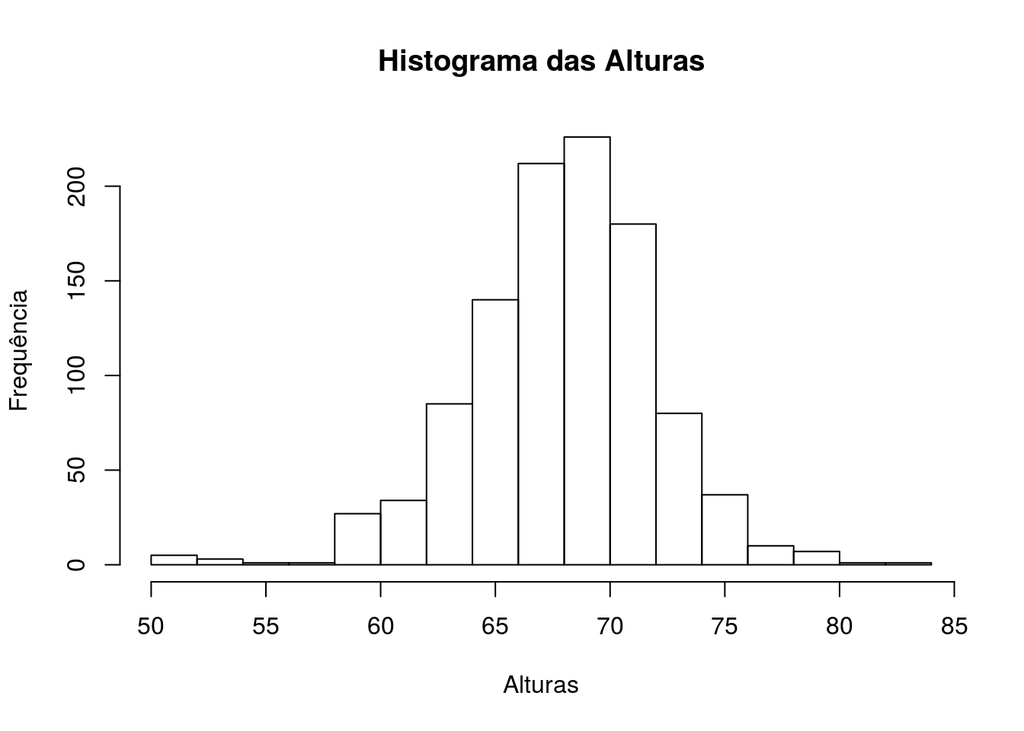

```r
hist(heights$height, main = "Histograma das Alturas", xlab = "Alturas",
     ylab = "Frequência")
```

A sétima questão me deixou na dúvida e, por isso, errei. A pergunta era qual a proporção de indivíduos que são do sexo masculino. Inicialmente, fiz com os operadores matemáticos.

Solicitei através do comando summary o resumo estatístico da variável sex afim de coletar quantos indivíduos estão alocados em cada grupo.

```r
summary(heights$sex)
```

```
## Female   Male
##    238    812
```

São 812 indivíduos do sexo masculino em um total de 1050.

```r
(812/1050)*100
```

```
## [1] 77.33333
```

A resposta inserida foi 77.33, mas estava incorreta. Você sabe o porque? Foi pedido a PROPORÇÃO e não a PORCENTAGEM. Logo, a resposta correta é 0.7733. É importante ressaltar aqui que o curso é 100% em inglês, e isso pode afetar algumas interpretações da minha parte.

Essa questão aborda condições, e a pergunta foi: Quantos indivíduos são mais altos do que 78 inches?

Inicialmente eu “buguei”. Esqueci algumas condições do R, dado que eu estava estudando SQL e Python. Então, a minha primeira forma de pensar foi verificar através de TRUE or FALSE.

```r
heights$height>78
```

[output not shown]

[output cut: 73 more lines]

Mas, eu não conseguia contar quantos TRUE haviam. E por isso comecei a pensar em qual forma seria mais fácil fazer contagem. Foi aí que pensei no table e consegui chegar a resposta correta.

```r
table(heights$height>78) #quantos são maiores que 78
```

```
##
## FALSE  TRUE
##  1041     9
```

Essa questão é bem parecida com a 8, mas com um pequeno diferencial. Quantos indivíduos do sexo feminino são mais altos do que 78 inches?

Tentei de várias formas. Mas, a solução foi obtida através do comando table novamente.

```r
table(heights$height>78 & heights$sex == "Female")
```

```
##
## FALSE  TRUE
##  1048     2
```